# Cylinder Count’s Effect on Price Retention

## Background

When deciding which car to purchase, it can sometimes be difficult to know exactly how much each vehicle is worth when judging the fairness of its price. Therefore, this analysis will attempt to determine: is there a linear relationship between mileage and price, modified by the number of cylinders the vehicle’s engine has?

The dataset utilized lists the prices, mileage, and number of cylinders for ~800 American vehicles, arranged by make/model. To avoid irrelevant outliers, the Cadillac XLR-V8 was removed from the data set, as its price is abnormally high for other 8 cylinder vehicles in the dataset.

Let us define the model and hypotheses that will be used to examine this question. Utilizing a Multiple linear regression model will result in:

$$\underbrace{Y_i}_{\text{Price}} = \overbrace{\beta_0 + \beta_1
\underbrace{X_{i1}}_{\text{Mileage}}}^{\text{4 Cylinders}} +
\overbrace{\beta_2 \underbrace{X_{i2}}_{\text{6 Cylinders}} + \beta_3
\underbrace{X_{i1} X_{i2}}_{\text{Interaction}}}^{\text{6 Cylinder
adjustments to the line}} + \overbrace{\beta_4
\underbrace{X_{i3}}_{\text{8 Cylinders}} + \beta_5 \underbrace{X_{i1}
X_{i3}}_{\text{Interaction}}}^{\text{8 Cylinder adjustments to the
line}} + \epsilon_i$$

where $\epsilon_i\sim N(0,\sigma^2)$. This results in the following:

| No. of Cylinders | Resulting Model |
| --- | --- |
| 4 | $Y_i = \beta_0 + \beta_1 X_{i1} + \epsilon_i$ |
| 6 | $Y_i = (\beta_0 + \beta_2) + (\beta_1 + \beta_3) X_{i1} + \epsilon_i$ |
| 8 | $Y_i = (\beta_0 + \beta_4) + (\beta_1 + \beta_5) X_{i1} + \epsilon_i$ |

These separate models illustrate that $\beta_2$ is the difference between y-intercepts for 6-cylinder vehicles, and $\beta_4$ the difference for 8-Cylinder vehicles. Additionally, $\beta_3$ and $\beta_5$ are the differences in slope applied for 6 and 8 cylinder vehicles respectively.

Based upon this background and model, this analysis will test several hypotheses to determine if price retention is modified by number of cylinders:

### Test for Linear Relationship

If there is a linear relationship between the price and the mileage, the cost of 4-cylinder vehicles will decrease as mileage increases. This hypothesis will be judged at $\alpha = .05$.

$$H_0: \beta_1 = 0 \quad \text{(There is no relationship between price
and mileage)} \\
H_a: \beta_1 \neq 0 \quad \text{(There is a linear relationship
between price and mileage)}$$

### Test for Equal Slopes

If $\beta_3 \ \text{and} \ \beta_5$ are zero, then the vehicle’s having 6 or 8 cylinders will not affect the slope of price retention. However, if they are not zero, there is an effect upon price retention due to engine cylinders. This hypothesis will be judged at $\alpha = .05$.
$$H_0: \beta_3 = 0 \quad \text{(Having 6 cylinders has no effect upon
price retention)} \\
H_a: \beta_3 \neq 0 \quad \text{(Having 6 cylinders has an effect upon
price retention)} \\
\ \\
H_0: \beta_5 = 0 \quad \text{(Having 8 cylinders has no effect upon
price retention)} \\
H_a: \beta_5 \neq 0 \quad \text{(Having 8 cylinders has an effect upon
price retention)}$$

## Analysis

In order to test these hypotheses, we must first determine whether the testing assumptions have been met. There are five test assumptions for a linear regression, as follows: 1. The regression relation between $Y$ and $X$ is linear.  
2. The error terms are normally distributed with $E\{\epsilon_i\} = 0$  
3. The variance of the error terms is constant over all $X$ values.  
4. The $X$ values can be considered fixed and measured without error.  
5. The error terms are independent.

Because the order this data was collected in is irrelevant, we can assume that the error terms are independent and that the $X$ values are fixed and measured without error. However, a plot of residuals vs order is provided to indicate how assumption 5 would be checked if there was question as to its veracity.

Next, a Residuals vs. Fitted plot will allow us to determine whether the relationship between $Y$ and $X$ is linear, as well as whether the variance of error terms is constant.

Lastly, a Q-Q plot of error terms will allow us to determine if error terms are normally distributed.

### Diagnostic plots

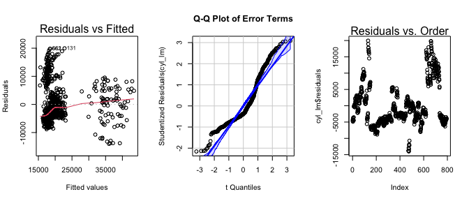

```r
#set plot settings so all three diagnostic plots are on one line
par(mfrow = c(1,3))
#Residuals vs. fitted plot for linearity/constant variance,
plot(cyl_lm, which = 1)
#Q-Qplot for normal error terms
qqPlot(cyl_lm, id = FALSE, main = "Q-Q Plot of Error Terms", cex = 1)
#Residuals vs. Order plot for independence of X values
plot(cyl_lm$residuals)
#add title to Residuals vs. order plot
mtext(text = "Residuals vs. Order")
```

```r
#reset plot settings
par(mfrow = c(1,1))
```

### Graphical Summary

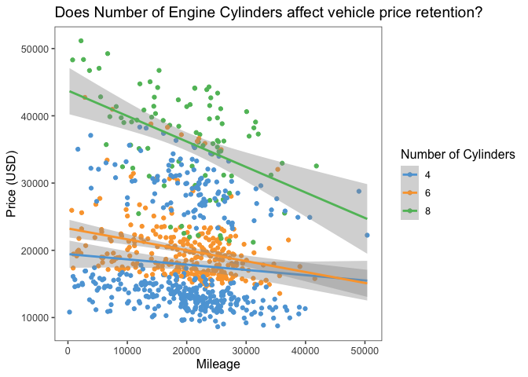

```r
#make plot of data
ggplot(CarPrices, aes(Mileage, Price, color = as.factor(Cylinder))) +
  #turn ggplot object into a scatterplot
  geom_point() +
  #use the FEW theme from ggthemes to beautify
  theme_few() +
  #adjust plot colors to match the ggtheme
  scale_color_few() +
  #add slope estimate lines to the plot with confidence intervals
  geom_smooth(formula = "y ~ x" ,method = lm, fullrange = TRUE) +
  #alter legend title
  guides(color = guide_legend(title = "Number of Cylinders")) +
  #add/modify graph titles
  labs(title = "Does Number of Engine Cylinders affect vehicle price retention?",
       x = "Mileage",
       y = "Price (USD)")
```

### Hypothesis Test

```r
pander(summary(cyl_lm), caption = "Linear Regression of Price according to Mileage and Cylinder count")
```

|  | Estimate | Std. Error | t value | Pr(>\|t\|) |
| --- | --- | --- | --- | --- |
| **(Intercept)** | 19439 | 870.6 | 22.33 | 5.981e-86 |
| **Mileage** | -0.07839 | 0.04007 | -1.957 | 0.05075 |
| **Cylinders6** | 3812 | 1322 | 2.883 | 0.004047 |
| **Cylinders8** | 24316 | 1960 | 12.41 | 2.05e-32 |
| **Mileage:Cylinders6** | -0.08363 | 0.0619 | -1.351 | 0.1771 |
| **Mileage:Cylinders8** | -0.3005 | 0.09135 | -3.289 | 0.00105 |

Linear Regression of Price according to Mileage and Cylinder count

| Observations | Residual Std. Error | $R^2$ | Adjusted $R^2$ |
| --- | --- | --- | --- |
| 794 | 6549 | 0.442 | 0.4385 |

As could be inferred from the plot of the data, the estimated slope adjustment for the 6 Cylinder group is very small (-.08), while the adjustment for 8 Cylinders is relatively much larger (-.3). The same is true for their P values, $P = .1771 \ \text{and} \ P = .00105$ respectively, indicating that the 8 Cylinder group’s slope adjustment is statistically significant while the 6 Cylinder group’s is not $(\alpha = .05)$. Additionally, the Mileage by itself has a $P = .051$, just over the level of significance.

## Interpretation

Although the assumptions for performing these tests could not be met, an interpretation will be provided here for what a valid test with these statistics would indicate. First, although the model utilized revealed that there is insufficient evidence of a Linear relationship between 4 cylinder vehicle’s price and their mileage, this value is so close to the level of significance that minor adjustments to the model (perhaps by removing irrelevant items like the y-intercepts) would most likely yield a significant value and allow us to reject the null hypothesis $H_0: \beta_1 = 0$. Second, The Test for Equal Slopes. This is more intriguing, as there is sufficient evidence to reject $\beta_5 = 0$—indicating that vehicles with 8 engine cylinders have a different rate of price retention than those with 4—but NOT sufficient evidence to reject $\beta_3 = 0$. This indicates that there is no significant difference in price retention rates for 6 and 4 cylinder vehicles. It would be interesting to determine if this 8-cylinder pattern holds true for non-American vehicles, as well as whether even higher cylinder-count engines have more dramatic price retention slopes.